# Ex7_results_ZW

Zoey Werbin

3/19/2019

In this assignment, we create a forecast for tree growth using forest inventory data that tracks diameter at breast height along with tree ring data. Let’s start by loading our packages and our data.

```r
if(!require(PEcAn.data.land)){
  suppressMessages(library(devtools))
  install.packages(c("digest","dplR","PeriodicTable"),repos = "https://cloud.r-project.org")
  devtools::install_github("PecanProject/pecan/base/logger")
  devtools::install_github("PecanProject/pecan/base/remote")
  devtools::install_github("PecanProject/pecan/base/utils")
  devtools::install_github("PecanProject/pecan/base/db")
  devtools::install_github("PecanProject/pecan/modules/data.land")
  suppressMessages(library(PEcAn.data.land))
}
suppressMessages(library(rjags))
library(ecoforecastR)

## 1. Read tree data
trees <- read.csv("data/H2012AdultFieldData.csv")

## 2. Read tree ring data
rings <- Read_Tucson("data/TUCSON/")
```

[output not shown]

[output cut: 272 more lines]

```r
## 3. merge inventory and tree ring data, extract most recent nyears
combined <- matchInventoryRings(trees,rings,nyears=15)

## take a look at the first few rows of data to see the structure
knitr::kable(combined[1:5,])
```

|  | SITE | PLOT | SUB | TAG | TREEID | NUM | SPP | X | Y | DATE11 | DBH11 | DBH12 | DATE_CORE_COLLECTED11 | DATE12 | DATE_CORE_COLLECT12 | 1998 | 1999 | 2000 | 2001 | 2002 | 2003 | 2004 | 2005 | 2006 | 2007 | 2008 | 2009 | 2010 | 2011 | … |
| --- | --- | --- | --- | --- | --- | --- | --- | --- | --- | --- | --- | --- | --- | --- | --- | --- | --- | --- | --- | --- | --- | --- | --- | --- | --- | --- | --- | --- | --- | --- |
| H6A1501 | H | 6 | A | 1501 | H6A1501 | 1 | PRSE2 | 1.2 | 0.6 | 7/10/11 | 24.8 | 24.75 | 7/10/11 | 7/2/12 | 7/2/12 | 2.433 | 1.357 | 1.300 | 1.301 | 1.108 | 1.303 | 0.870 | 0.951 | 1.319 | 1.431 | 1.253 | 1.381 | 1.107 | 0.686 | … |
| H6A1502 | H | 6 | A | 1502 | H6A1502 | 1 | ACRU | 0.2 | 2.0 | 7/10/11 | 24.2 | 24.5 | 7/10/11 | 7/2/12 | 7/2/12 | 1.227 | 0.581 | 1.066 | 0.950 | 1.387 | 0.917 | 1.084 | 1.824 | 1.513 | 2.099 | 2.066 | 1.603 | 0.744 | 2.104 | … |
| H6A1505 | H | 6 | A | 1505 | H6A1505 | 1 | ACRU | 3.9 | 3.4 | 7/10/11 | 16.75 | 16.75 | 7/10/11 | 7/2/12 | 7/2/12 | 0.939 | 0.750 | 0.867 | 0.656 | 0.457 | 0.822 | 0.529 | 0.698 | 0.381 | 0.465 | 0.233 | 0.433 | 0.275 | 0.180 | … |
| H6A1506 | H | 6 | A | 1506 | H6A1506 | 1 | BEAL2 | 5.7 | 3.2 | 7/10/11 | 17.2 | 17.2 | 7/10/11 | 7/2/12 | 7/2/12 | 0.979 | 0.595 | 0.561 | 0.958 | 0.821 | 0.765 | 0.804 | 0.635 | 1.143 | 0.485 | 0.825 | 0.439 | 1.028 | 0.361 | … |
| H6A1507 | H | 6 | A | 1507 | H6A1507 | 1 | TSCA | 8.2 | 5.5 | 7/10/11 | 30.1 | 30.4 | 7/10/11 | 7/2/12 | 7/2/12 | 0.624 | 0.536 | 0.444 | 0.408 | 0.272 | 0.720 | 0.519 | 1.842 | 1.701 | 1.749 | 1.344 | 1.373 | 1.277 | 1.106 | … |

```r
## 4. organize data into a list
data <- buildJAGSdata_InventoryRings(combined)
# y = increment (tree x year)
# z = dbh (tree x year)
# make sure to take a look at all the priors!
# str(data)
```

# Assignment:

### 1. Run the model initially with random effects off.

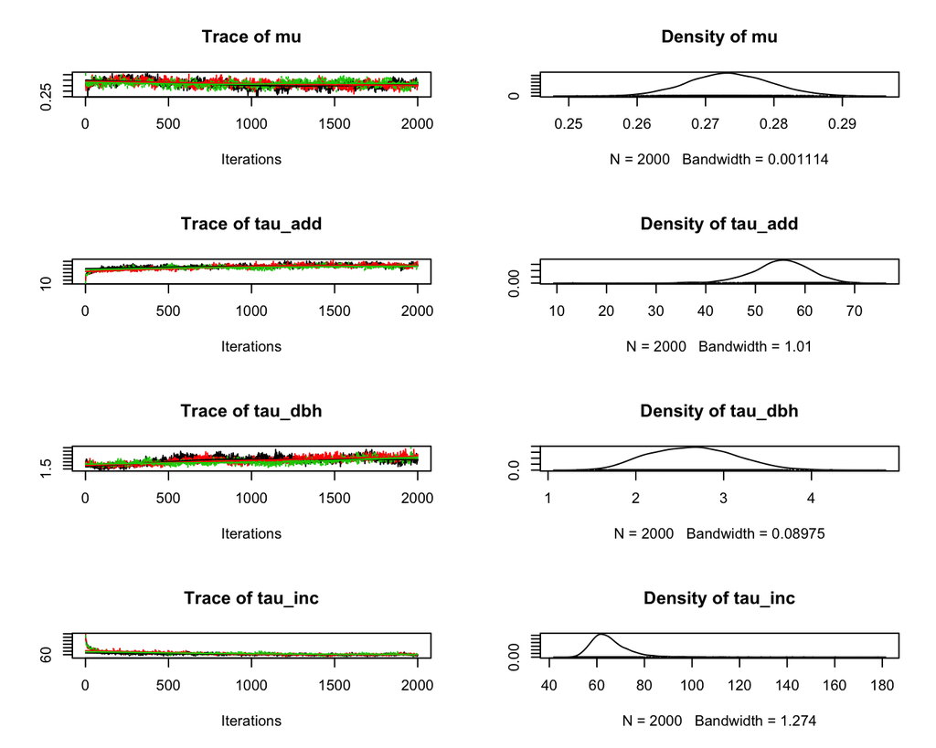

```r
n.iter = 20000

## this code fuses forest inventory data with tree growth data (tree ring or dendrometer band)
## for the same plots. Code is a rewrite of Clark et al 2007 Ecol Appl into JAGS
TreeDataFusionMV = "
model{

### Loop over all individuals
for(i in 1:ni){

  #### Data Model: DBH
  for(t in 1:nt){
  z[i,t] ~ dnorm(x[i,t],tau_dbh)
  }

  #### Data Model: growth
  for(t in 2:nt){
  inc[i,t] <- x[i,t]-x[i,t-1]
  y[i,t] ~ dnorm(inc[i,t],tau_inc)
  }

  #### Process Model
  for(t in 2:nt){
  Dnew[i,t] <- x[i,t-1] + mu
  x[i,t]~dnorm(Dnew[i,t],tau_add)
  }

  x[i,1] ~ dnorm(x_ic,tau_ic)

}  ## end loop over individuals

  #### Priors
  tau_dbh ~ dgamma(a_dbh,r_dbh)
  tau_inc ~ dgamma(a_inc,r_inc)
  tau_add ~ dgamma(a_add,r_add)
  mu ~ dnorm(0.5,0.5)
}"

  ## state variable initial condition (subtract observed diameter increments off from the observed diameter)
  z0 = t(apply(data$y,1,function(y){-rev(cumsum(rev(y)))})) + data$z[,ncol(data$z)]

  ## JAGS initial conditions
  nchain = 3
  init <- list()
  for(i in 1:nchain){
    y.samp = sample(data$y,length(data$y),replace=TRUE)
    init[[i]] <- list(x = z0,tau_add=runif(1,1,5)/var(diff(y.samp),na.rm=TRUE),
                      tau_dbh=1,tau_inc=500,tau_ind=50,tau_yr=100,ind=rep(0,data$ni),year=rep(0,data$nt))
  }

  ## compile JAGS model
  j.model   <- jags.model (file = textConnection(TreeDataFusionMV),
                           data = data,
                           inits = init,
                           n.chains = 3)
  # we get a bunch of errors because there are some variables we aren't using until we incorporate random effects.

  ## burn-in
  jags.out   <- coda.samples (model = j.model,
                              variable.names = c("tau_add","tau_dbh","tau_inc","mu","tau_ind","tau_yr"),
                              n.iter = min(n.iter,2000))
  plot(jags.out)
```

```r
  ## run MCMC
  jags.out   <- coda.samples (model = j.model,
                              variable.names = c("x","tau_add","tau_dbh","tau_inc","mu",
                                                 "tau_ind","tau_yr","ind","year"),
                              n.iter = n.iter)
```

All chains have converged. Good.

### 2. Rerun the model with random effects on. Compare this to the previous run. What is the relative partitioning of uncertainties in the different versions of the model among observation error, process error, and the different random effects? What does the size of these effects suggest about the drivers of uncertainty in tree growth?

```r
n.iter = 20000
# Random effects case

TreeDataFusion_RE = "
model{

### Loop over all individuals
for(i in 1:ni){

  #### Data Model: DBH
  for(t in 1:nt){
    z[i,t] ~ dnorm(x[i,t],tau_dbh)
  }

  #### Data Model: growth
  for(t in 2:nt){
    inc[i,t] <- x[i,t]-x[i,t-1]
    y[i,t] ~ dnorm(inc[i,t],tau_inc)
  }

  #### Process Model
  for(t in 2:nt){
    Dnew[i,t] <- x[i,t-1] + mu + ind[i] + year[t]
    x[i,t]~dnorm(Dnew[i,t],tau_add)
  }

  ## individual effects
  ind[i] ~ dnorm(0,tau_ind)

  ## initial condition
  x[i,1] ~ dnorm(x_ic,tau_ic)

}  ## end loop over individuals

  ## year effects
  for(t in 1:nt){
    year[t] ~ dnorm(0,tau_yr)
  }


  #### Priors
  tau_dbh ~ dgamma(a_dbh,r_dbh)
  tau_inc ~ dgamma(a_inc,r_inc)
  tau_add ~ dgamma(a_add,r_add)
  tau_ind ~ dgamma(1,0.1)
  tau_yr  ~ dgamma(1,0.1)
  mu ~ dnorm(0.5,0.5)

  }"

  ## state variable initial condition (subtract observed diameter increments off from the observed diameter)
  z0 = t(apply(data$y,1,function(y){-rev(cumsum(rev(y)))})) + data$z[,ncol(data$z)]

  ## JAGS initial conditions
  nchain = 3
  init <- list()
  for(i in 1:nchain){
    y.samp = sample(data$y,length(data$y),replace=TRUE)
    init[[i]] <- list(x = z0,tau_add=runif(1,1,5)/var(diff(y.samp),na.rm=TRUE),
                      tau_dbh=1,tau_inc=500,tau_ind=50,tau_yr=100,ind=rep(0,data$ni),year=rep(0,data$nt))
  }

  ## compile JAGS model
  j.model_RE   <- jags.model (file = textConnection(TreeDataFusion_RE),
                           data = data,
                           inits = init,
                           n.chains = 3)
```

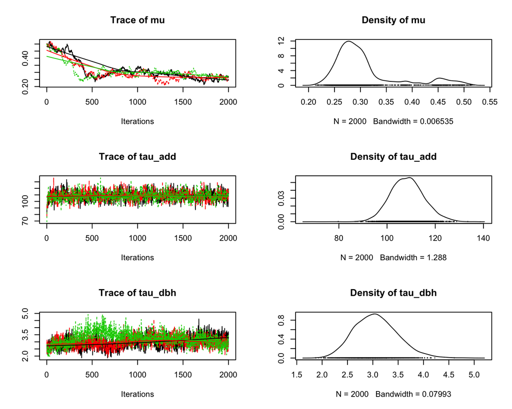

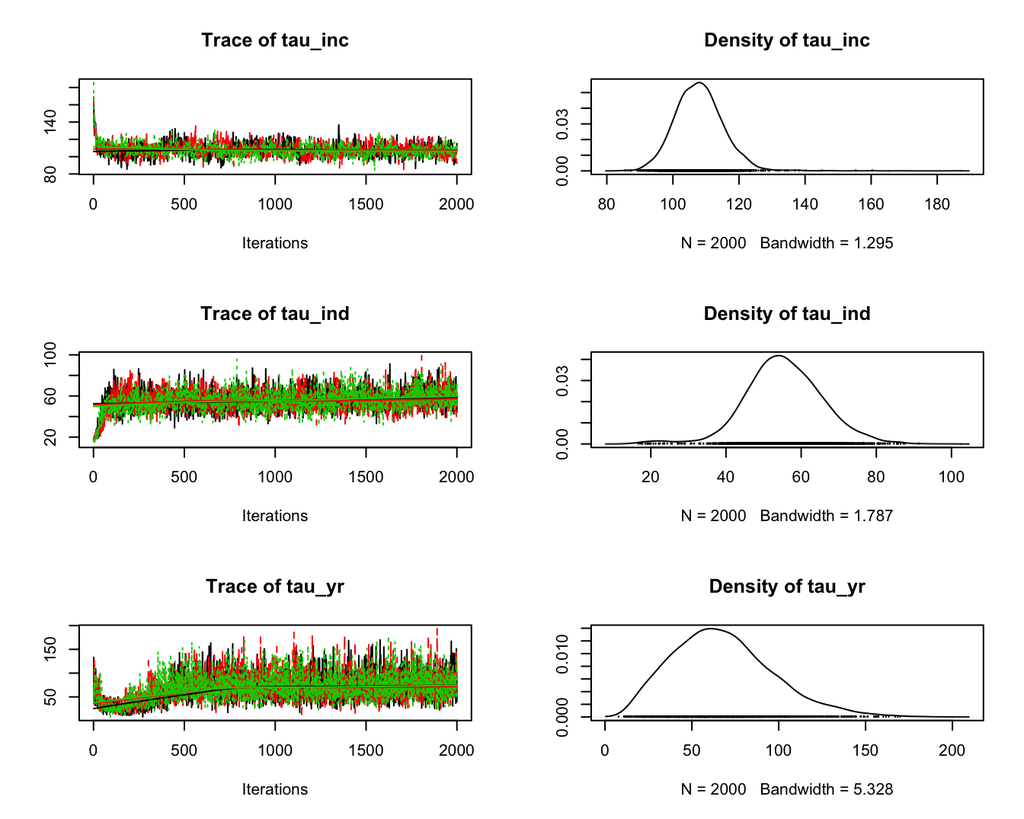

```r
  ## burn-in
  jags.out_RE   <- coda.samples (model = j.model_RE,
                              variable.names = c("tau_add","tau_dbh","tau_inc","mu","tau_ind","tau_yr"),
                              n.iter = min(n.iter,2000))
  plot(jags.out_RE)
```

```r
  ## run MCMC
  jags.out_RE   <- coda.samples (model = j.model_RE,
                              variable.names = c("x","tau_add","tau_dbh","tau_inc","mu",
                                                 "tau_ind","tau_yr","ind","year"),
                              n.iter = n.iter)
```

Now, to compare the models with and without random effects, let’s look at the diagnostics for each. Without random effects:

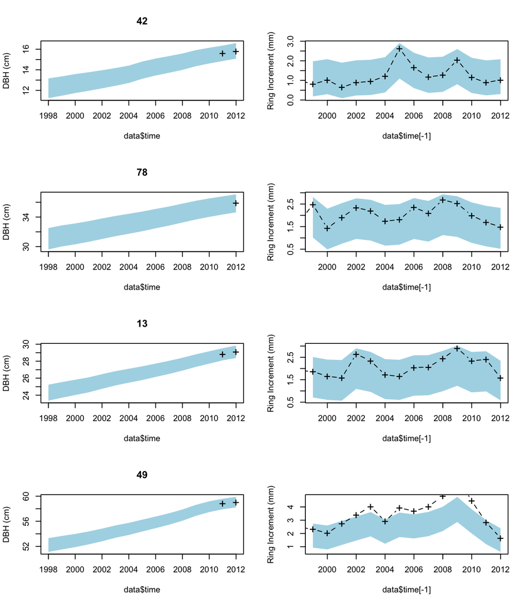

```r
#### Diagnostic plots without random effects

  ### DBH
  layout(matrix(1:8,4,2))
  out <- as.matrix(jags.out)
  x.cols = which(substr(colnames(out),1,1)=="x")   ## which columns are the state variable, x
  ci <- apply(out[,x.cols],2,quantile,c(0.025,0.5,0.975))
  ci.names = parse.MatrixNames(colnames(ci),numeric=TRUE)

  smp = c(sample.int(data$ni,3),49)  ## I've rigged the sampling to make sure you see tree 49!
  for(i in smp){
    sel = which(ci.names$row == i)
    plot(data$time,ci[2,sel],type='n',ylim=range(ci[,sel],na.rm=TRUE),ylab="DBH (cm)",main=i)
    ciEnvelope(data$time,ci[1,sel],ci[3,sel],col="lightBlue")
    points(data$time,data$z[i,],pch="+",cex=1.5)
  }

  ## growth
  for(i in smp){
    sel = which(ci.names$row == i)
    inc.mcmc = apply(out[,x.cols[sel]],1,diff)
    inc.ci = apply(inc.mcmc,1,quantile,c(0.025,0.5,0.975))*5

    plot(data$time[-1],inc.ci[2,],type='n',ylim=range(inc.ci,na.rm=TRUE),ylab="Ring Increment (mm)")
    ciEnvelope(data$time[-1],inc.ci[1,],inc.ci[3,],col="lightBlue")
    points(data$time,data$y[i,]*5,pch="+",cex=1.5,type='b',lty=2)
  }
```

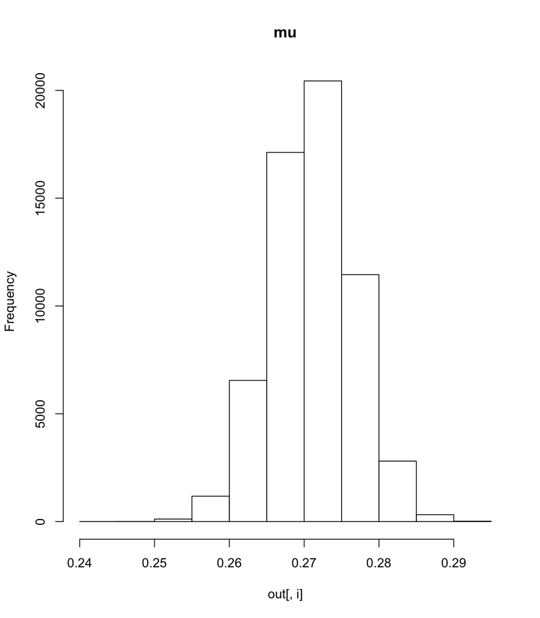

```r
    ## process model
  vars = (1:ncol(out))[-c(which(substr(colnames(out),1,1)=="x"),grep("tau",colnames(out)),
                          grep("year",colnames(out)),grep("ind",colnames(out)))]
  par(mfrow=c(1,1))
  for(i in vars){
    hist(out[,i],main=colnames(out)[i])
  }
```

```r
  if(length(vars)>1) pairs(out[,vars])

  ## Standard Deviations
  par(mfrow=c(2,3))
  prec = out[,grep("tau",colnames(out))]
  for(i in 1:ncol(prec)){
    hist(1/sqrt(prec[,i]),main=colnames(prec)[i])
  }
  cor(prec)
```

```
##             tau_add     tau_dbh     tau_inc
## tau_add  1.00000000  0.02735731 -0.36528246
## tau_dbh  0.02735731  1.00000000 -0.01613687
## tau_inc -0.36528246 -0.01613687  1.00000000
```

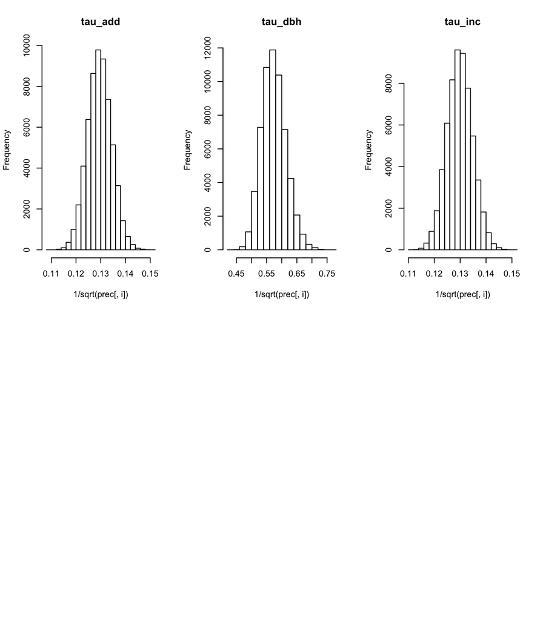

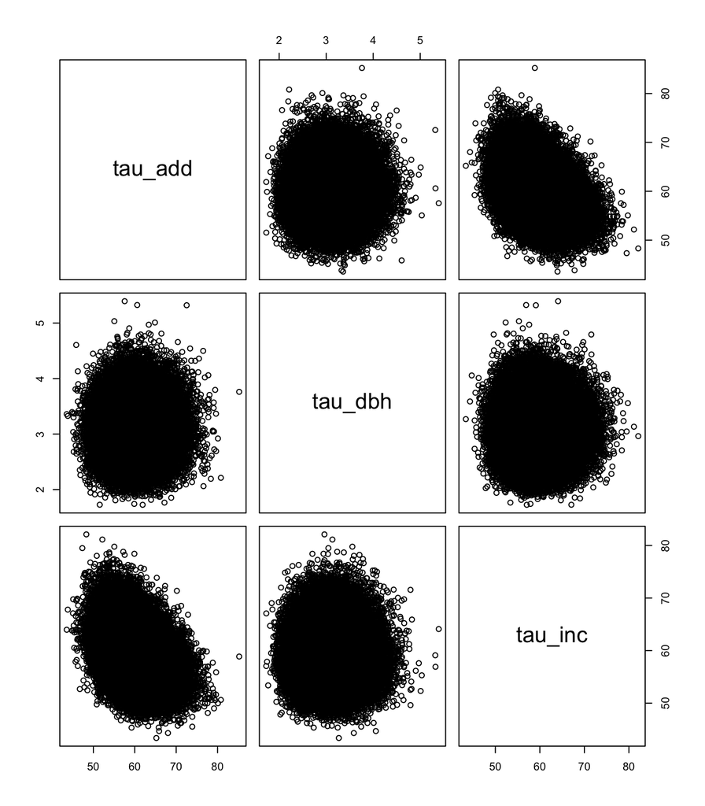

```r
  pairs(prec)
```

With random effects:

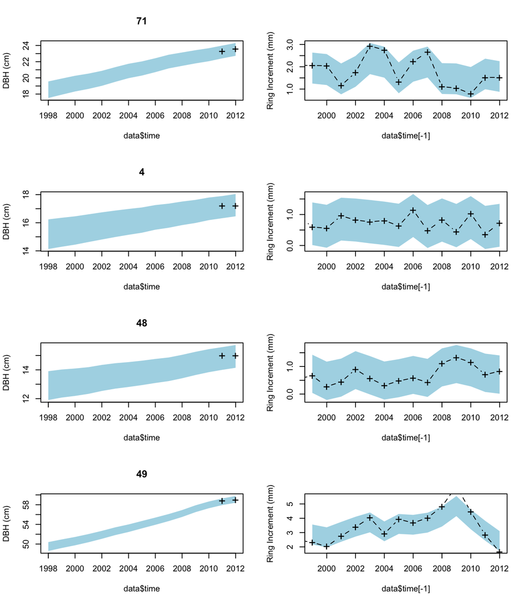

```r
#### Diagnostic plots

  ### DBH
  layout(matrix(1:8,4,2))
  out <- as.matrix(jags.out_RE)
  x.cols = which(substr(colnames(out),1,1)=="x")   ## which columns are the state variable, x
  ci <- apply(out[,x.cols],2,quantile,c(0.025,0.5,0.975))
  ci.names = parse.MatrixNames(colnames(ci),numeric=TRUE)

  smp = c(sample.int(data$ni,3),49)  ## I've rigged the sampling to make sure you see tree 49!
  for(i in smp){
    sel = which(ci.names$row == i)
    plot(data$time,ci[2,sel],type='n',ylim=range(ci[,sel],na.rm=TRUE),ylab="DBH (cm)",main=i)
    ciEnvelope(data$time,ci[1,sel],ci[3,sel],col="lightBlue")
    points(data$time,data$z[i,],pch="+",cex=1.5)
  }

  ## growth
  for(i in smp){
    sel = which(ci.names$row == i)
    inc.mcmc = apply(out[,x.cols[sel]],1,diff)
    inc.ci = apply(inc.mcmc,1,quantile,c(0.025,0.5,0.975))*5

    plot(data$time[-1],inc.ci[2,],type='n',ylim=range(inc.ci,na.rm=TRUE),ylab="Ring Increment (mm)")
    ciEnvelope(data$time[-1],inc.ci[1,],inc.ci[3,],col="lightBlue")
    points(data$time,data$y[i,]*5,pch="+",cex=1.5,type='b',lty=2)
  }
```

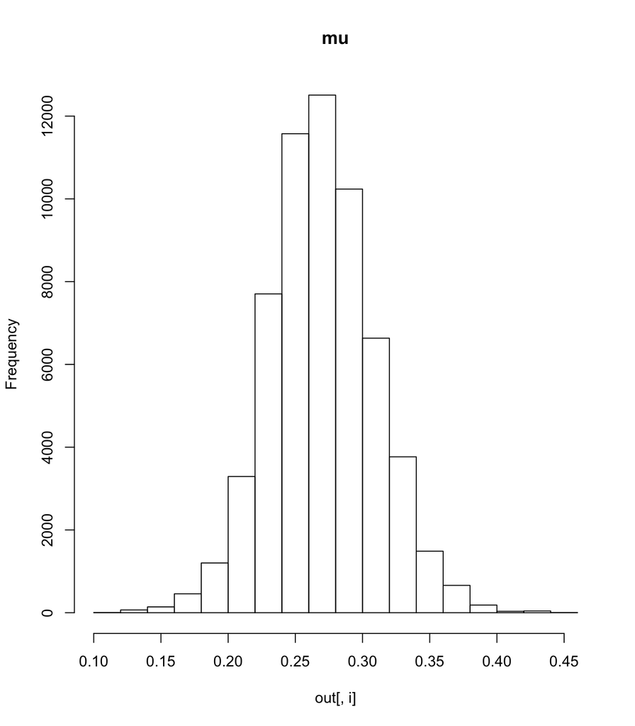

```r
    ## process model
  vars = (1:ncol(out))[-c(which(substr(colnames(out),1,1)=="x"),grep("tau",colnames(out)),
                          grep("year",colnames(out)),grep("ind",colnames(out)))]
  par(mfrow=c(1,1))
  for(i in vars){
    hist(out[,i],main=colnames(out)[i])
  }
```

```r
  if(length(vars)>1) pairs(out[,vars])

  ## Standard Deviations
  par(mfrow=c(2,3))
  prec = out[,grep("tau",colnames(out))]
  for(i in 1:ncol(prec)){
    hist(1/sqrt(prec[,i]),main=colnames(prec)[i])
  }
  cor(prec)
```

```
##              tau_add      tau_dbh      tau_inc       tau_ind        tau_yr
## tau_add  1.000000000 -0.003645934 -0.093936802 -0.0127539670 -0.0014215145
## tau_dbh -0.003645934  1.000000000 -0.007970059 -0.0133567256  0.0033411439
## tau_inc -0.093936802 -0.007970059  1.000000000 -0.0151914296  0.0099549435
## tau_ind -0.012753967 -0.013356726 -0.015191430  1.0000000000 -0.0002819516
## tau_yr  -0.001421514  0.003341144  0.009954943 -0.0002819516  1.0000000000
```

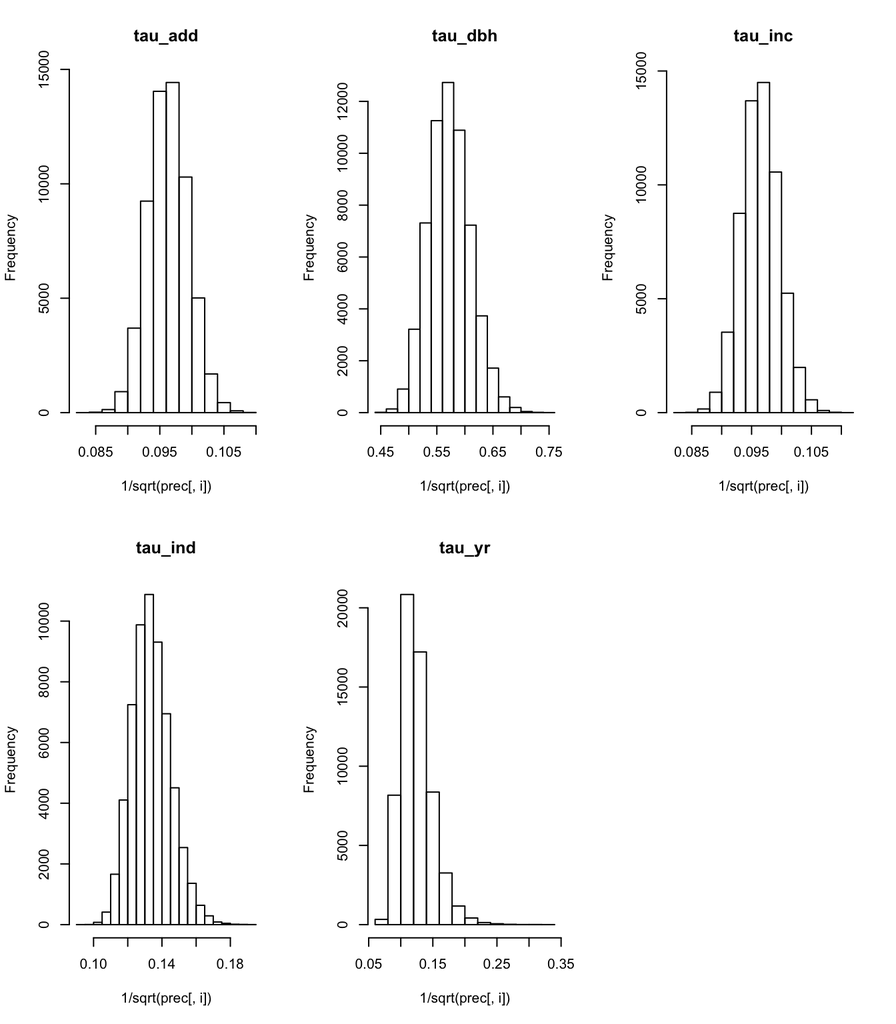

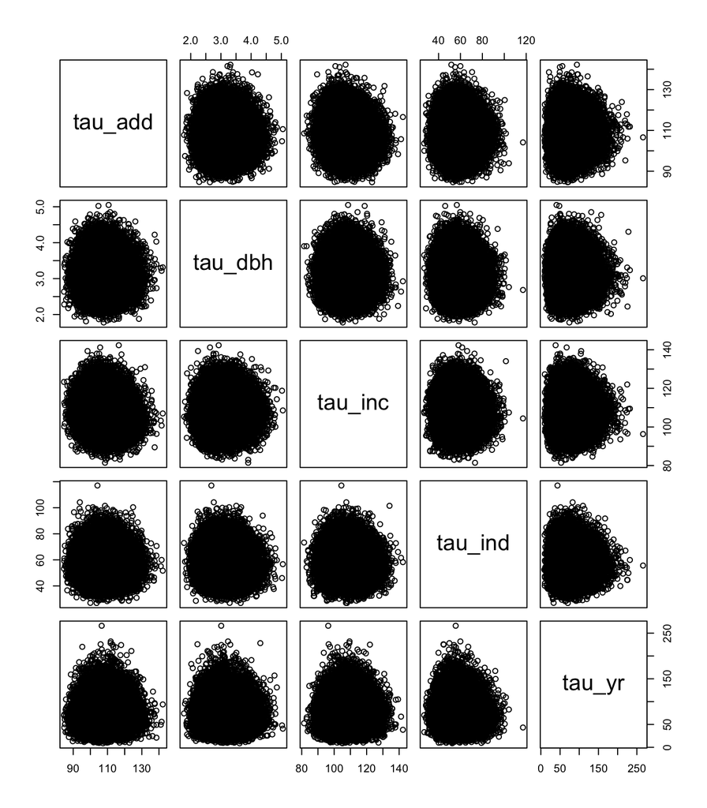

```r
  pairs(prec)
```

The confidence intervals shrink a bit, and include more of the observed data points, once we add random effects.

The error partitioned to random effects of either year or individual are both larger than that assigned to process error or to growth, indicating that these are significant drivers of uncertainty within this model. DBH remains a large source of uncertainty even when these random effects are accounted for.

### 3. Based on the diagnostics, propose an additional effect (fixed or random) to add to the model. Such an effect should plausibly chip away at a sizable fraction of the unexplained variability – you wouldn’t want to propose an effect that isn’t associated with systematic variability.

I propose a random effect due to variation between plots. All study plots were located within Harvard Forest in Petersham, MA, but each plot could have had slightly different conditions - ex. one plot might be at a lower elevation where water pools and causes anoxic soil, or another plot may be at the edge of the forest and have more access to sunlight. This could chip away at the process error uncertainty that still remains. I’m giving tau_plot a gamma prior distribution so that the values are zero-bound and continuous.

### 4. Explain any additional exploratory analyses you would perform (e.g. plotting your proposed covariate against one of the random effects).

Plot effects could be explored by visualizing the growth rates over time split up by plot - this could highlight whether certain plots have categorically lower or higher growth rates than others.

### 5. Write the JAGS code that would fit the proposed model (note: you don’t have to track down additional covariate data or run this model, just propose the code)

```
TreeDataFusion_RE = "
model{

### Loop over all individuals
for(i in 1:ni){

  #### Data Model: DBH
  for(t in 1:nt){
    z[i,t] ~ dnorm(x[i,t],tau_dbh)
  }

  #### Data Model: growth
  for(t in 2:nt){
    inc[i,t] <- x[i,t]-x[i,t-1]
    y[i,t] ~ dnorm(inc[i,t],tau_inc)
  }

  #### Process Model
  for(t in 2:nt){
    Dnew[i,t] <- x[i,t-1] + mu + ind[i] + year[t] + plot[p]
    x[i,t]~dnorm(Dnew[i,t],tau_add)
  }

  ## individual effects
  ind[i] ~ dnorm(0,tau_ind)

  ## initial condition
  x[i,1] ~ dnorm(x_ic,tau_ic)

}  ## end loop over individuals

  ## year effects
  for(t in 1:nt){
    year[t] ~ dnorm(0,tau_yr)
  }

  # plot effects
  for(p in 1:np){
    plot[p] ~ dnorm(0,tau_plot)
  }

  #### Priors
  tau_dbh ~ dgamma(a_dbh,r_dbh)
  tau_inc ~ dgamma(a_inc,r_inc)
  tau_add ~ dgamma(a_add,r_add)
  tau_ind ~ dgamma(1,0.1)
  tau_plot ~ dgamma(1,0.1)
  tau_yr  ~ dgamma(1,0.1)
  mu ~ dnorm(0.5,0.5)

  }"
```